# DATA 605 Final

Jeff Shamp

2020-05-18

# Problem 1

Using R, generate a random variable X that has 10,000 random uniform numbers from 1 to N, where N can be any number of your choosing greater than or equal to 6. Then generate a random variable Y that has 10,000 random normal numbers with a mean of μ=σ=(N+1)/2.

**We will set up some parameters, check that it works, and then calculate the probabilities.**

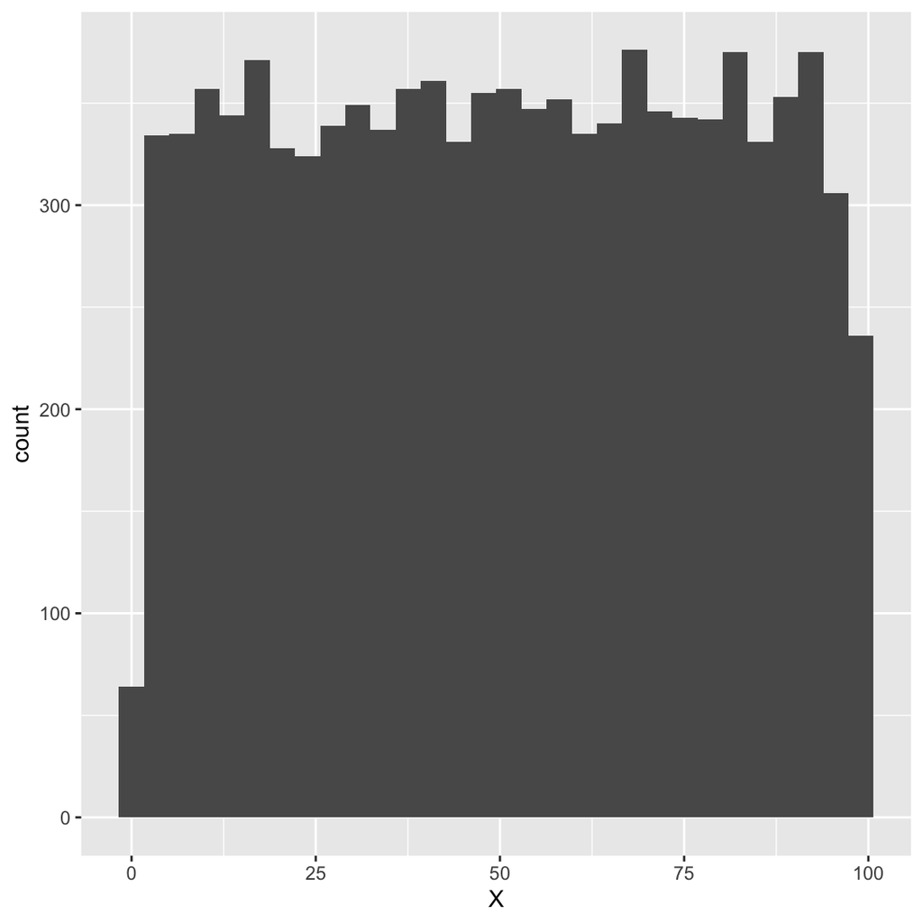

```r
set.seed(945945)
N<- 100
samp<-10000
mu<- (N+1)/2
sd<-mu
X<- runif(n = samp, min = 1, max = N)
Y<- rnorm(n = N, mean = mu, sd = sd)
df_1<- data.frame(X=X, Y=Y)
df_1 %>%
  ggplot() +
  geom_histogram(aes(X))
```

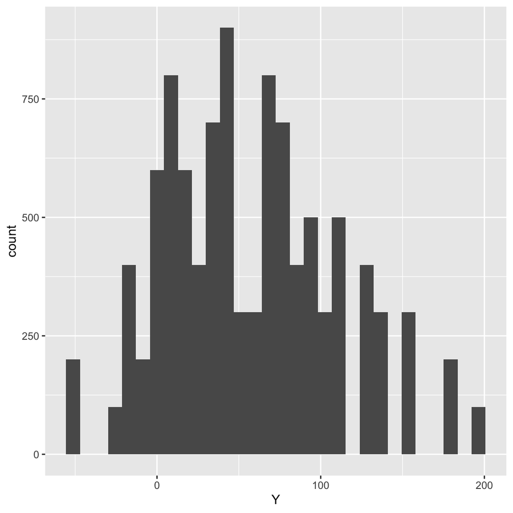

```r
df_1 %>%
  ggplot() +
  geom_histogram(aes(Y))
```

## Probability

Calculate as a minimum the below probabilities a through c. Assume the small letter “x” is estimated as the median of the X variable, and the small letter “y” is estimated as the 1st quartile of the Y variable. Interpret the meaning of all probabilities.

### Part A

P(X>x | X>y)

**We will define x and y first.**

```r
x<-quantile(df_1$X, 0.5)
y<-quantile(df_1$Y, 0.25)
paste("Median of X: ",x,"First quantile of Y: ",y)
```

```
[1] "Median of X:  50.450980646885 First quantile of Y:  16.0447103644291"
```

**This is a conditional probability that X>x given that X>y. We want to know the probabiity that given X>y ~16, that is the chance that X>~50.**

```r
P_b_a<- df_1 %>% # prob of both conditions
  filter(X > x, X > y) %>%
  nrow()/samp
P_a<- df_1 %>% # prob that X is already > y
  filter(X > y) %>%
  nrow()/samp
P_a_b<- P_b_a / P_a
paste("Probability of X>x given that X>y = ",P_a_b)
```

```
[1] "Probability of X>x given that X>y =  0.58913632614587"
```

**Here we see that X > y and X > x exactly half the time and X > y ~.85, so it makes sense that there is a slight increase in the probability that X > than the median given that X > the first quantile of y.**

### Part B

P(X>x, Y>y)

**This one is two separate varibales to it does not need a conditional term.**

```r
df_1 %>%
  filter(X > x, Y > y) %>%
  nrow()/samp
```

```
[1] 0.3768
```

**So X is greater than the median of X AND Y is greater than it’s first quantile, 37.68% of the time.**

### Part C

P(X<x | X>y)

**This is will be a similar set up to the part A. When is X less than it’s median given that it is greater than the first quantile of Y.**

```r
P_b_a<- df_1 %>%
  filter(X < x, X > y) %>%
  nrow()/samp

P_a<- df_1 %>%
  filter(X > y) %>%
  nrow()/samp

P_a_b<- P_b_a/P_a
paste("Probability that X < x given that X > y = ",P_a_b)
```

```
[1] "Probability that X < x given that X > y =  0.41086367385413"
```

## Marginal and Joint Probabilities

Investigate whether P(X>x and Y>y)=P(X>x)P(Y>y) by building a table and evaluating the marginal and joint probabilities.

**I’m going to do this brute force style, calculate each probability and then corral them into a dataframe to show.**

```r
# filter for conditions
XY_ls_xy<- df_1 %>% filter(X < x, Y < y) %>% nrow()/samp
X_gt_x_Y_ls_y <- df_1 %>% filter(X > x, Y < y) %>% nrow()/samp
X_ls_x_Y_gt_y <- df_1 %>% filter(X < x, Y > y) %>% nrow()/samp
XY_gt_xy<- df_1 %>% filter(X > x, Y > y) %>% nrow()/samp

prob_table<- as.data.frame(matrix(c(XY_ls_xy, X_gt_x_Y_ls_y,
                                    X_ls_x_Y_gt_y, XY_gt_xy),
                                  byrow = TRUE,
                                  nrow = 2))
prob_table$Total<- apply(prob_table,1,sum) # row wise sums
prob_table[3,"V1"]<-sum(prob_table$V1, na.rm = TRUE) # get column sums
prob_table[3,"V2"]<-sum(prob_table$V2, na.rm= TRUE)
prob_table[3,"Total"]<-sum(prob_table$Total, na.rm = TRUE)
rownames(prob_table)<- c("Y < y", "Y > y", "Total")
DT::datatable(prob_table %>% rename("X < x" = "V1", "X > x" = "V2"),
              extensions = c('FixedColumns',"FixedHeader"),
              options = list(scrollX = FALSE,
                         paging=FALSE,
                         fixedHeader=FALSE,
                         dom  = 't'))
```

|  | X < x | X > x | Total |
| --- | --- | --- | --- |
| Y &lt; y | 0.1268 | 0.1232 | 0.25 |
| Y &gt; y | 0.3732 | 0.3768 | 0.75 |
| Total | 0.5 | 0.5 | 1 |

**There is a small difference between the P(X>x and Y>y) and P(X>x)*P(Y>y), but the difference is 0.0018**

## Independence Test

Check to see if independence holds by using Fisher’s Exact Test and the Chi Square Test. What is the difference between the two? Which is most appropriate?

**We are now to perform two tests on the contingency table for the above data to determine if X and Y are independent. First, let’s get the contingency table, then we can easily perform the tests. Fisher’s test works for all samples so it can be a fine tool for this job. Chi-Square can also be used for independence and is works best with a large sample, which we have. A key difference between these tests is that Fisher’s is an exact calculation of p-value and Chi squared is an approximation from the sampling distribution.**

**In both of these tests we see that with a very large p-value we fail to reject the null hypothesis. These variables are independent, which I would expect given that they come from two different, random, independent variables.**

```r
count_table<- prob_table[1:2,1:2]*samp # use prob_table to get counts
DT::datatable(count_table %>% rename("X < x" = "V1", "X > x" = "V2"),
              extensions = c('FixedColumns',"FixedHeader"),
              options = list(scrollX = FALSE,
                         paging=FALSE,
                         fixedHeader=FALSE,
                         dom  = 't'))
```

|  | X < x | X > x |
| --- | --- | --- |
| Y &lt; y | 1268 | 1232 |
| Y &gt; y | 3732 | 3768 |

```r
count_table<- count_table %>% rename("X < x" = "V1", "X > x" = "V2")
fisher.test(count_table)
```

```
    Fisher's Exact Test for Count Data

data:  count_table
p-value = 0.4189
alternative hypothesis: true odds ratio is not equal to 1
95 percent confidence interval:
 0.9482096 1.1388313
sample estimates:
odds ratio
  1.039161
```

```r
chisq.test(count_table)
```

```
    Pearson's Chi-squared test with Yates' continuity correction

data:  count_table
X-squared = 0.65333, df = 1, p-value = 0.4189
```

# Problem 2

Kaggle username : jeffshamp

Kaggle Competition Score : 0.17735

```r
# Just showing the first six columns
d<- getURL("https://raw.githubusercontent.com/Shampjeff/cuny_msds/master/DATA_605/final_project/train.csv")
train_df<- read.csv(text=d, stringsAsFactors = FALSE)
DT::datatable(train_df[,1:6],
         extensions = c('FixedColumns',"FixedHeader"),
          options = list(scrollX = TRUE,
                         paging=TRUE,
                         fixedHeader=TRUE,
                         pageLengh=7))
```

|  | Id | MSSubClass | MSZoning | LotFrontage | LotArea | Street |
| --- | --- | --- | --- | --- | --- | --- |
| 1 | 1 | 60 | RL | 65 | 8450 | Pave |
| 2 | 2 | 20 | RL | 80 | 9600 | Pave |
| 3 | 3 | 60 | RL | 68 | 11250 | Pave |
| 4 | 4 | 70 | RL | 60 | 9550 | Pave |
| 5 | 5 | 60 | RL | 84 | 14260 | Pave |
| 6 | 6 | 50 | RL | 85 | 14115 | Pave |
| 7 | 7 | 20 | RL | 75 | 10084 | Pave |
| 8 | 8 | 60 | RL |  | 10382 | Pave |
| 9 | 9 | 50 | RM | 51 | 6120 | Pave |
| 10 | 10 | 190 | RL | 50 | 7420 | Pave |

[output cut: 1450 more lines]

## Descriptive and Inferential Statistics

### Descriptive Statistics

Provide univariate descriptive statistics and appropriate plots for the training data set.

```r
print("GrLivArea: Above grade (ground) living area square feet")
```

```
[1] "GrLivArea: Above grade (ground) living area square feet"
```

```r
summary(train_df$GrLivArea)
```

```
   Min. 1st Qu.  Median    Mean 3rd Qu.    Max.
    334    1130    1464    1515    1777    5642
```

```r
print("Sale Price - target variable")
```

```
[1] "Sale Price - target variable"
```

```r
summary(train_df$SalePrice)
```

```
   Min. 1st Qu.  Median    Mean 3rd Qu.    Max.
  34900  129975  163000  180921  214000  755000
```

```r
print("TotalBsmtSF: Total square feet of basement area")
```

```
[1] "TotalBsmtSF: Total square feet of basement area"
```

```r
summary(train_df$TotalBsmtSF)
```

```
   Min. 1st Qu.  Median    Mean 3rd Qu.    Max.
    0.0   795.8   991.5  1057.4  1298.2  6110.0
```

```r
print("LotArea: Lot size in square feet")
```

```
[1] "LotArea: Lot size in square feet"
```

```r
summary(train_df$LotArea)
```

```
   Min. 1st Qu.  Median    Mean 3rd Qu.    Max.
   1300    7554    9478   10517   11602  215245
```

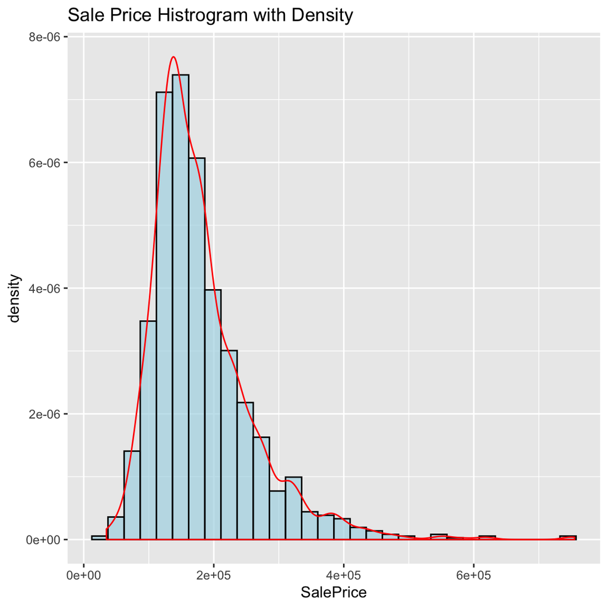

```r
train_df %>%
  ggplot(aes(x=SalePrice)) +
  geom_histogram(aes(y=..density..),
                 fill="lightblue",color="black", alpha=0.7) +
  geom_density(color="red") +
  labs(title="Sale Price Histrogram with Density")
```

```r
train_df %>%
  ggplot(aes(x=GrLivArea)) +
  geom_histogram(aes(y=..density..),
                 fill="lightblue",color="black", alpha=0.7) +
  geom_density(color="red") +
  labs(title="Above Ground Living Area Histrogram with Density")
```

[output not shown]

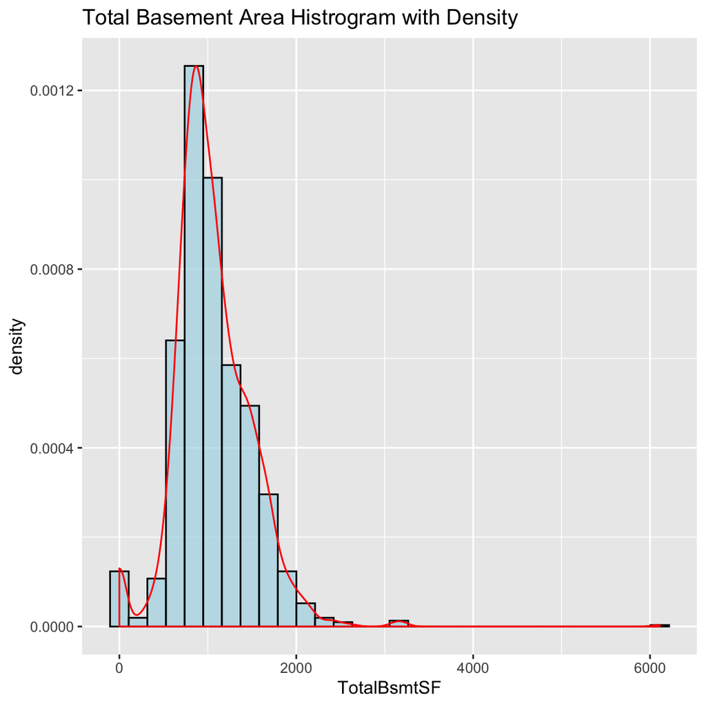

```r
train_df %>%
  ggplot(aes(x=TotalBsmtSF)) +
  geom_histogram(aes(y=..density..),
                 fill="lightblue",color="black", alpha=0.7) +
  geom_density(color="red") +
  labs(title="Total Basement Area Histrogram with Density")
```

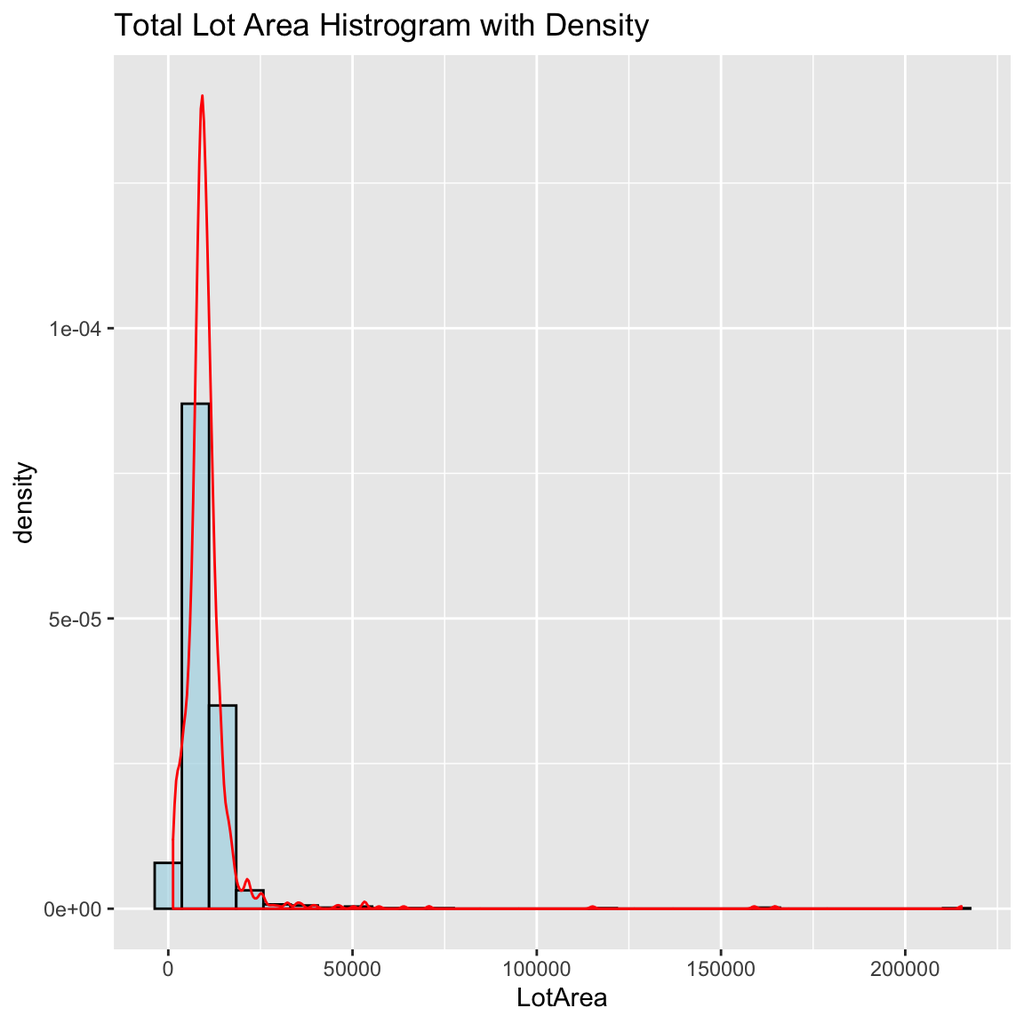

```r
train_df %>%
  ggplot(aes(x=LotArea)) +
  geom_histogram(aes(y=..density..),
                 fill="lightblue",color="black", alpha=0.7) +
  geom_density(color="red") +
  labs(title="Total Lot Area Histrogram with Density")
```

### Scatterplot Matrix

Provide a scatterplot matrix for at least two of the independent variables and the dependent variable.

**A plot of the Overall Quality variable is included below. Looks to be quadratic.**

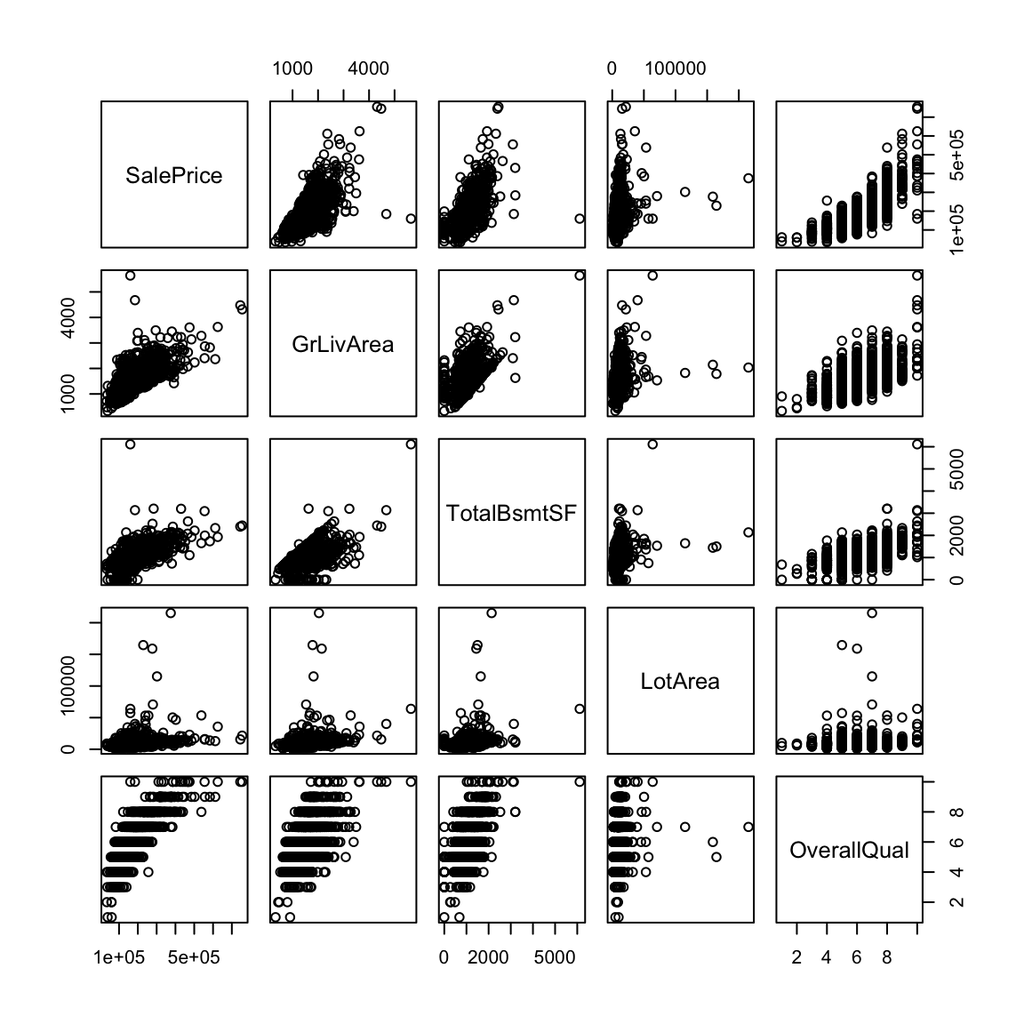

```r
pairs(train_df %>% dplyr::select(SalePrice, GrLivArea,
                                 TotalBsmtSF, LotArea, OverallQual))
```

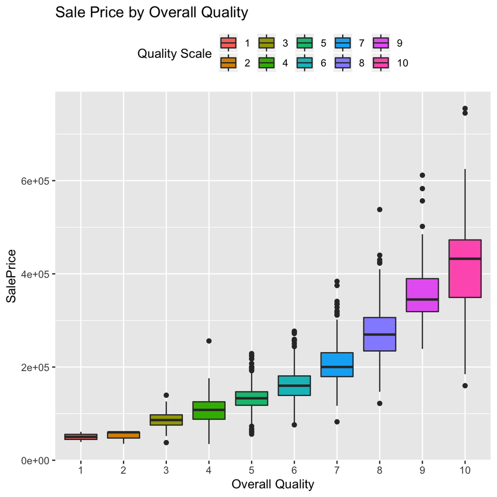

```r
train_df %>%
  ggplot(aes(x=factor(OverallQual), y=SalePrice, fill=factor(OverallQual))) +
  geom_boxplot() +
  labs(x= "Overall Quality", title="Sale Price by Overall Quality") +
  theme(legend.position = "top") +
  guides(fill=guide_legend(title="Quality Scale"))
```

### Correlation Matrix

Derive a correlation matrix for any three quantitative variables in the dataset.

```r
cor_matrix<- train_df %>%
  dplyr::select(SalePrice, GrLivArea, TotalBsmtSF) %>%
  cor() %>%
  as.matrix()
cor_matrix
```

```
            SalePrice GrLivArea TotalBsmtSF
SalePrice   1.0000000 0.7086245   0.6135806
GrLivArea   0.7086245 1.0000000   0.4548682
TotalBsmtSF 0.6135806 0.4548682   1.0000000
```

### Hypothesis Testing

Test the hypotheses that the correlations between each pairwise set of variables is 0 and provide an 80% confidence interval. Discuss the meaning of your analysis.

Correlation Test with 80% confidence interval for GrLivArea

```r
cor.test(train_df$GrLivArea, train_df$SalePrice, conf.level = 0.8)
```

```
    Pearson's product-moment correlation

data:  train_df$GrLivArea and train_df$SalePrice
t = 38.348, df = 1458, p-value < 2.2e-16
alternative hypothesis: true correlation is not equal to 0
80 percent confidence interval:
 0.6915087 0.7249450
sample estimates:
      cor
0.7086245
```

Correlation Test with 80% confidence interval for Total Basemnet SqFt

```r
cor.test(train_df$TotalBsmtSF, train_df$SalePrice, conf.level = 0.8)
```

```
    Pearson's product-moment correlation

data:  train_df$TotalBsmtSF and train_df$SalePrice
t = 29.671, df = 1458, p-value < 2.2e-16
alternative hypothesis: true correlation is not equal to 0
80 percent confidence interval:
 0.5922142 0.6340846
sample estimates:
      cor
0.6135806
```

```r
cor.test(train_df$GrLivArea, train_df$TotalBsmtSF, conf.level = 0.8)
```

```
    Pearson's product-moment correlation

data:  train_df$GrLivArea and train_df$TotalBsmtSF
t = 19.503, df = 1458, p-value < 2.2e-16
alternative hypothesis: true correlation is not equal to 0
80 percent confidence interval:
 0.4278380 0.4810855
sample estimates:
      cor
0.4548682
```

**We see that for each pairwise comparison the p-value is very small, so can safely reject the null hypothesis that each correaltion is actually zero.**

Would you be worried about familywise error? Why or why not?

```r
1-(1-0.05)^3
```

```
[1] 0.142625
```

## Linear Algebra and Correlation

### Invert Correlation Matrix

Invert your correlation matrix from above. (This is known as the precision matrix and contains variance inflation factors on the diagonal).

```r
precision_matrix<- solve(cor_matrix)
precision_matrix
```

```
             SalePrice   GrLivArea TotalBsmtSF
SalePrice    2.5582310 -1.38549273 -0.93946422
GrLivArea   -1.3854927  2.01124151 -0.06473842
TotalBsmtSF -0.9394642 -0.06473842  1.60588442
```

### Precision and Correlation Matricies

Multiply the correlation matrix by the precision matrix, and then multiply the precision matrix by the correlation matrix.

**Any matrix multiplied by it’s inverse should be the indentity matrix.**

```r
round(cor_matrix %*% precision_matrix)
```

```
            SalePrice GrLivArea TotalBsmtSF
SalePrice           1         0           0
GrLivArea           0         1           0
TotalBsmtSF         0         0           1
```

**The same must be true for the precision times correlation.**

```r
round(precision_matrix %*% cor_matrix)
```

```
            SalePrice GrLivArea TotalBsmtSF
SalePrice           1         0           0
GrLivArea           0         1           0
TotalBsmtSF         0         0           1
```

### LU Decomposition

Conduct LU decomposition on the matrix.

**Homegrown LU Decomposition function.**

```r
matrix.factorize<- function(input_mat){
  mat_L<-diag(dim(input_mat)[1])
  row_idx<-1
  for(j in 1:(dim(input_mat)[2]-1)){
    for(i in 1:(dim(input_mat)[1]-row_idx)){
      mat_L[i+row_idx,j]<-(input_mat[i+row_idx,j] /
                             input_mat[j,j])
      input_mat[i+row_idx,]<-((-1*mat_L[i+row_idx,j]) *
                                input_mat[row_idx,]) +
                                input_mat[i+row_idx,]
    }
  row_idx<-row_idx+1
  }
  return(list(input_mat, mat_L))
}
decomp<-matrix.factorize(cor_matrix)
```

```r
matrix(decomp[[1]],nrow=3)
```

```
     [,1]      [,2]      [,3]
[1,]    1 0.7086245 0.6135806
[2,]    0 0.4978513 0.0200700
[3,]    0 0.0000000 0.6227098
```

```r
decomp[[2]]
```

```
          [,1]       [,2] [,3]
[1,] 1.0000000 0.00000000    0
[2,] 0.7086245 1.00000000    0
[3,] 0.6135806 0.04031325    1
```

```r
decomp[[2]]%*%decomp[[1]]
```

```
     SalePrice GrLivArea TotalBsmtSF
[1,] 1.0000000 0.7086245   0.6135806
[2,] 0.7086245 1.0000000   0.4548682
[3,] 0.6135806 0.4548682   1.0000000
```

**We see that this is the original correlation matrix when L and U multiplied.**

## Calculus-Based Probability & Statistics

Many times, it makes sense to fit a closed form distribution to data. Select a variable in the Kaggle.com training dataset that is skewed to the right, shift it so that the minimum value is absolutely above zero if necessary.

**Recall `GrLivArea` as right skewed. We will apply a log transform this data**

```r
train_df %>%
  ggplot(aes(x=GrLivArea)) +
  geom_histogram(aes(y=..density..),
                 fill="lightblue",color="black", alpha=0.7) +
  geom_density(color="red") +
  labs(title="Above Ground Living Area Histrogram with Density")
```

[output not shown]

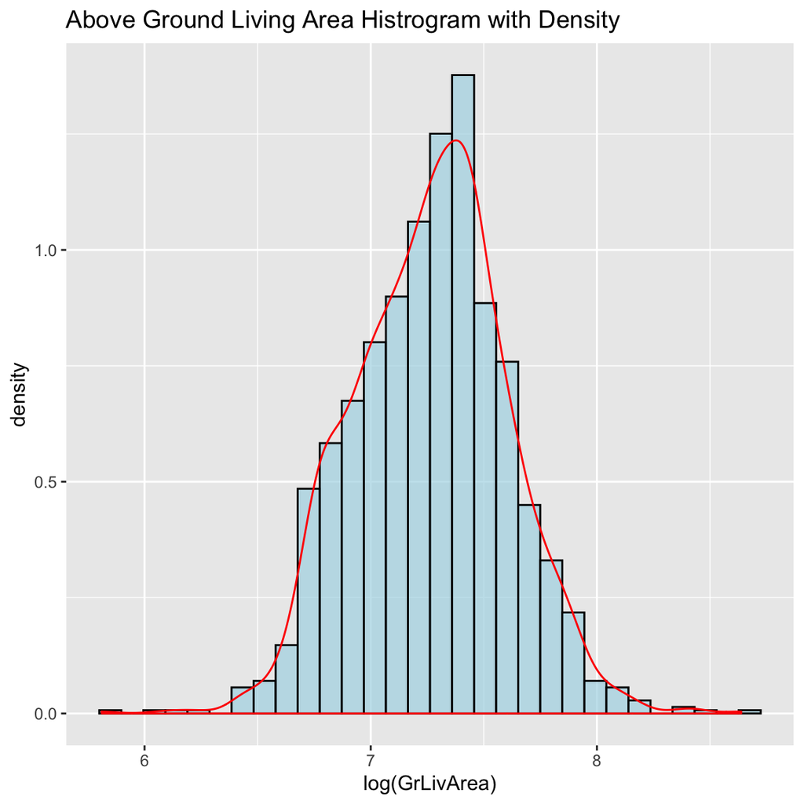

```r
train_df %>%
  ggplot(aes(x=log(GrLivArea))) +
  geom_histogram(aes(y=..density..),
                 fill="lightblue",color="black", alpha=0.7) +
  geom_density(color="red") +
  labs(title="Above Ground Living Area Histrogram with Density")
```

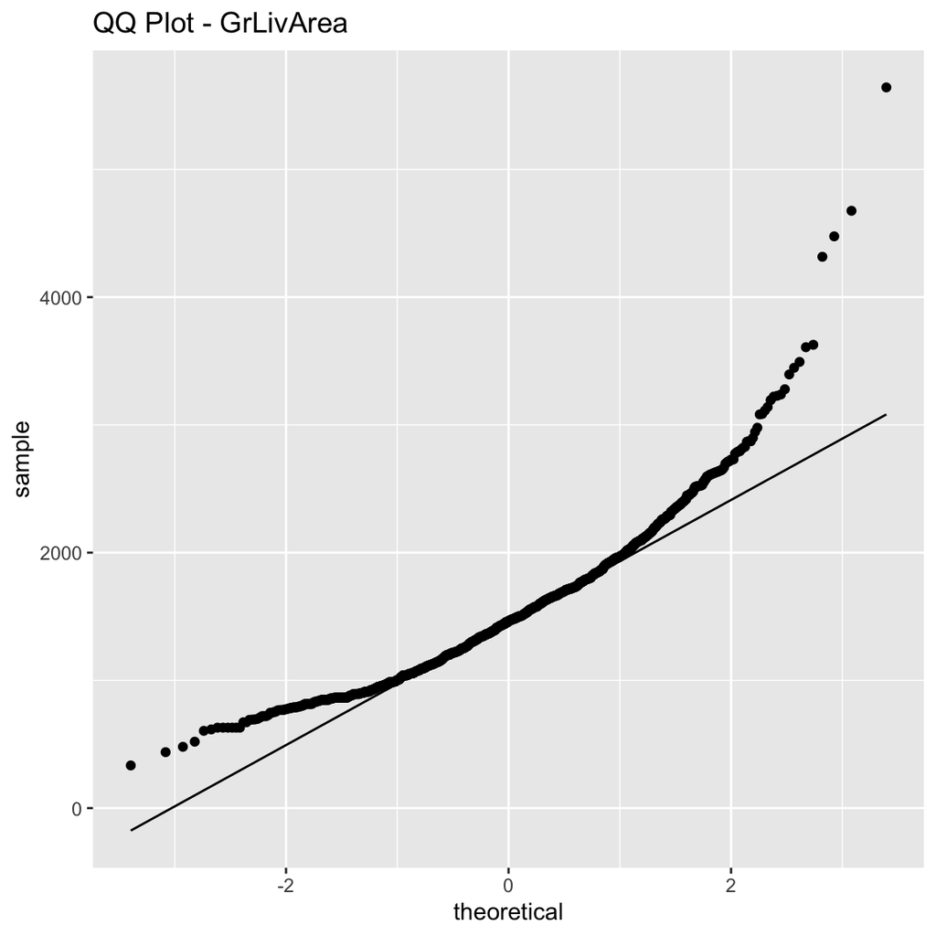

```r
train_df %>%
  ggplot(aes(sample=GrLivArea)) +
  stat_qq() +
  stat_qq_line() +
  labs(title="QQ Plot - GrLivArea")
```

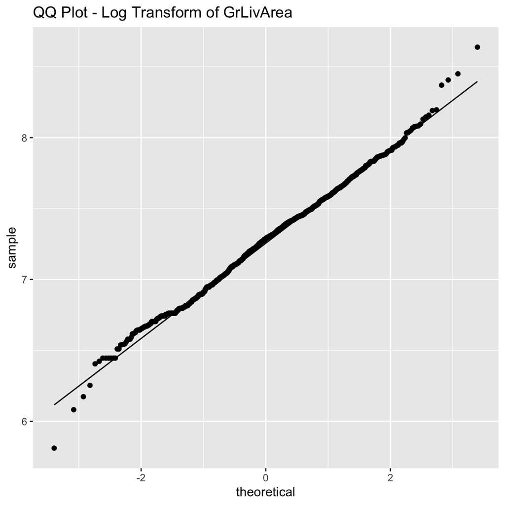

```r
train_df %>%
  ggplot(aes(sample=log(GrLivArea))) +
  stat_qq() +
  stat_qq_line() +
  labs(title="QQ Plot - Log Transform of GrLivArea")
```

### Optimum Lambda

Load the MASS package and run fitdistr to fit an exponential probability density function. Find the optimal value of λ for this distribution

```r
library(MASS)
exp_liv_area<- fitdistr(train_df$GrLivArea, "exponential")
exp_liv_area
```

```
       rate
  6.598640e-04
 (1.726943e-05)
```

### Sampling with Lambda

Take 1000 samples from this exponential distribution using this value (e.g., rexp(1000, λ)). Plot a histogram and compare it with a histogram of your original variable.

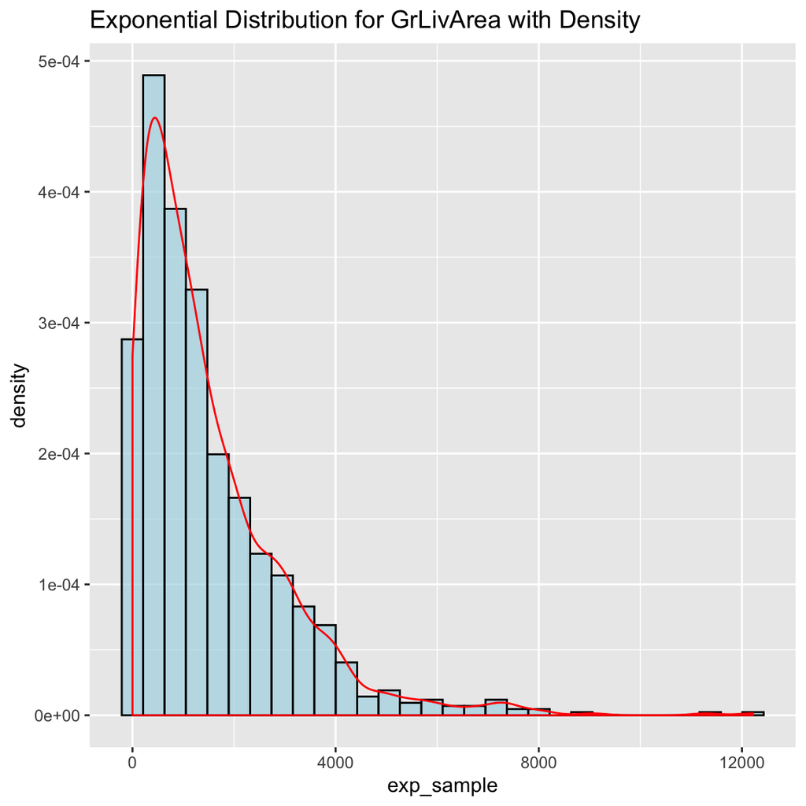

```r
exp_sample<-rexp(1000, exp_liv_area$estimate)

ggplot(as.data.frame(exp_sample), aes(x=exp_sample)) +
  geom_histogram(aes(y=..density..),
                 fill="lightblue",color="black", alpha=0.7) +
  geom_density(color="red") +
  labs(title="Exponential Distribution for GrLivArea with Density")
```

```r
train_df %>%
  ggplot(aes(x=GrLivArea)) +
  geom_histogram(aes(y=..density..),
                 fill="lightblue",color="black", alpha=0.7) +
  geom_density(color="red") +
  labs(title="Above Ground Living Area Histrogram with Density")
```

[output not shown]

### PDF, CI, and Percentiles

Using the exponential pdf, find the 5th and 95th percentiles using the cumulative distribution function (CDF). Also generate a 95% confidence interval from the empirical data, assuming normality. Finally, provide the empirical 5th percentile and 95th percentile of the data. Discuss.

**5th and 95th percentiles from the exponential distribution.**

```r
qexp(0.05, rate=exp_liv_area$estimate)
```

```
[1] 77.73313
```

```r
qexp(0.95, rate=exp_liv_area$estimate)
```

```
[1] 4539.924
```

**CI with assumed normality from the actual dataset.**

```r
SE<- sd(train_df$GrLivArea)/ (sqrt(length(train_df$GrLivArea)))
lower<- mean(train_df$GrLivArea) - 1.960*SE
upper<- mean(train_df$GrLivArea)+ 1.960*SE
paste("95% CI for above ground living area (GrLivArea): ",
      round(lower,3), " - ",round(upper,3) )
```

```
[1] "95% CI for above ground living area (GrLivArea):  1488.509  -  1542.419"
```

**Empircial 5th and 95th percentiles**

```r
quantile(train_df$GrLivArea, 0.05)
```

```
 5%
848
```

```r
quantile(train_df$GrLivArea, 0.95)
```

```
   95%
2466.1
```

**We see that this data is, in fact, skewed to the right considering the 5th/95th percentiles and the true mean and it’s 95% CI. The exponential distribution seems like an un-needed example in this context. Unless the was some kind of evidence that the data “shuold” be this way.**

## Modeling

Build some type of multiple regression model and submit your model to the competition board. Provide your complete model summary and results with analysis.

### General Approach

**I’ll keep this relatively simple. Let’s look at above ground area, below ground area, garage size and number of cars, and two measures of quality (house and garage). I think that several of these predictors could use a log transform to make them more normalized. Also it might be helpful to have at least one or two categorical variables; Overall Quality, and GarageQual seem like a nice candidates. Garage quality will take work to get the dummy variables. Additionally, the overall quality variable appears to quadratic so we will inlude that in the model.**

### Missing Values

**Let’s first check for missing values with our set of predictors.**

```r
train_df %>%
  dplyr::select(GrLivArea, SalePrice, TotalBsmtSF,
                OverallQual, GarageQual, GarageCars) %>%
  summarise_all(funs(sum(is.na(.))))
```

```
  GrLivArea SalePrice TotalBsmtSF OverallQual GarageQual GarageCars
1         0         0           0           0         81          0
```

```r
train_df<-train_df %>%
  dplyr::select(GrLivArea, SalePrice, TotalBsmtSF,
                OverallQual, GarageQual, GarageCars)
```

**We need to fill some values for Garage Quality. Let’s look at the most frequent rating.**

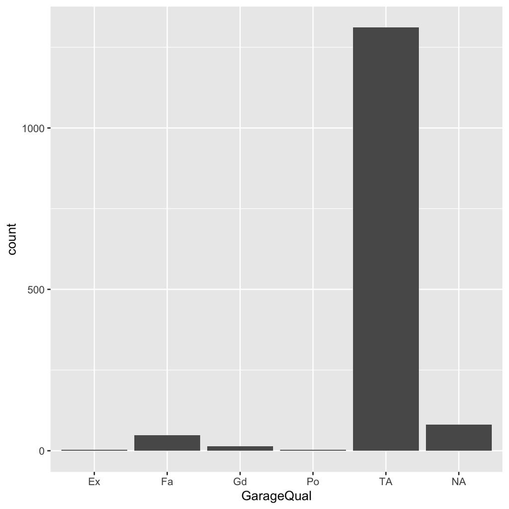

```r
train_df %>%
  ggplot(aes(x=GarageQual)) +
  geom_bar()
```

**We will fill NA’s with `TA` rating in garage quality.**

```r
train_df<- train_df %>%
  mutate(GarageQual = replace_na(GarageQual, "TA"))
```

### Check for Outliers

**I believe we have some outliers in GrLiveArea.**

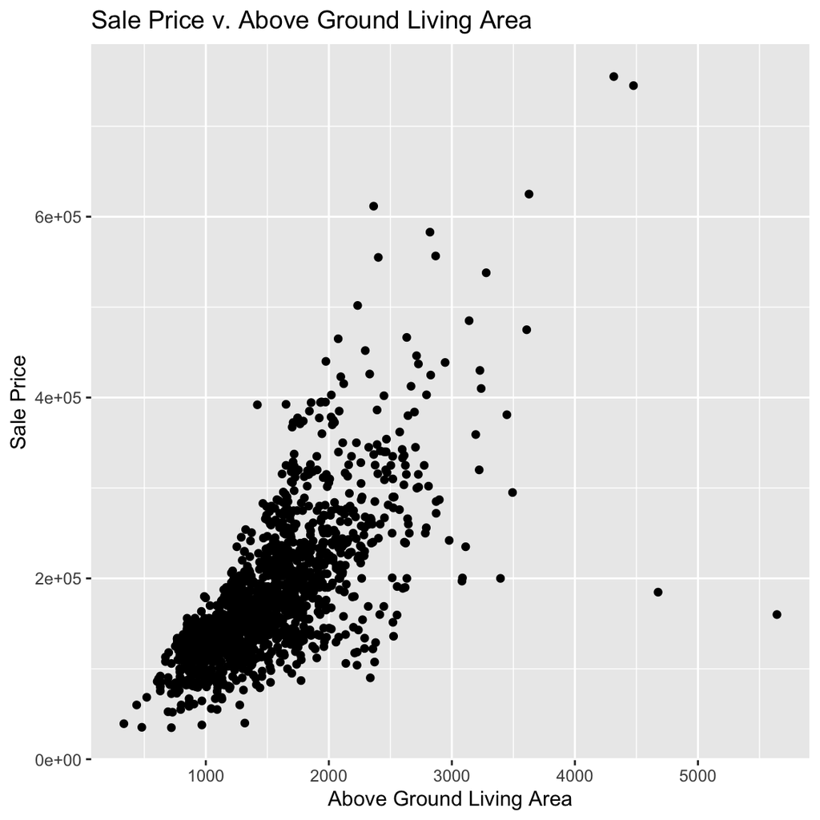

```r
train_df %>%
  dplyr::select(SalePrice, GrLivArea) %>%
  ggplot(aes(x=GrLivArea, y=SalePrice)) +
  geom_point() +
  labs(x="Above Ground Living Area",
       y="Sale Price",
       title="Sale Price v. Above Ground Living Area")
```

```r
z_score<- scale(train_df$GrLivArea)
train_df$GrLivArea_Z<- z_score
max(z_score)
```

```
[1] 7.852884
```

```r
train_df<- train_df %>%
  filter(GrLivArea_Z < 5)
```

### Categorical Variables

**We need to convert the garage quality variable from a categorical to dummy numerical values.**

```r
library(caret)
dmy <- dummyVars(" ~ .", data = train_df, fullRank = T)
train_df <- data.frame(predict(dmy, newdata = train_df))

glimpse(train_df)
```

```
Observations: 1,456
Variables: 10
$ GrLivArea    <dbl> 1710, 1262, 1786, 1717, 2198, 1362, 1694, 2090, 1774, 10…
$ SalePrice    <dbl> 208500, 181500, 223500, 140000, 250000, 143000, 307000, …
$ TotalBsmtSF  <dbl> 856, 1262, 920, 756, 1145, 796, 1686, 1107, 952, 991, 10…
$ OverallQual  <dbl> 7, 6, 7, 7, 8, 5, 8, 7, 7, 5, 5, 9, 5, 7, 6, 7, 6, 4, 5,…
$ GarageQualFa <dbl> 0, 0, 0, 0, 0, 0, 0, 0, 1, 0, 0, 0, 0, 0, 0, 0, 0, 0, 0,…
$ GarageQualGd <dbl> 0, 0, 0, 0, 0, 0, 0, 0, 0, 1, 0, 0, 0, 0, 0, 0, 0, 0, 0,…
$ GarageQualPo <dbl> 0, 0, 0, 0, 0, 0, 0, 0, 0, 0, 0, 0, 0, 0, 0, 0, 0, 0, 0,…
$ GarageQualTA <dbl> 1, 1, 1, 1, 1, 1, 1, 1, 0, 0, 1, 1, 1, 1, 1, 1, 1, 1, 1,…
$ GarageCars   <dbl> 2, 2, 2, 3, 3, 2, 2, 2, 2, 1, 1, 3, 1, 3, 1, 2, 2, 2, 2,…
$ GrLivArea_Z  <dbl> 0.37020659, -0.48234664, 0.51483616, 0.38352774, 1.29888…
```

### Multiple Regression

**Let’s try out regression and analyze the results. We tried garage area as well but found that it is not a better predictor than garage cars. Additionally, the categories for `GarageQual` have been deleted as the result of backward selection for predictors whose p-values were above 0.05 critical values (fails to reject null hypothesis for non-zero slope). In the end we have a relatively simple model, this produces the best results on the competition.**

```r
lin_reg<- lm(data=train_df, log(SalePrice) ~ log(GrLivArea)+ TotalBsmtSF +
               I(OverallQual^2) + GarageCars)

summary(lin_reg)
```

```
Call:
lm(formula = log(SalePrice) ~ log(GrLivArea) + TotalBsmtSF +
    I(OverallQual^2) + GarageCars, data = train_df)

Residuals:
     Min       1Q   Median       3Q      Max
-1.02521 -0.08202  0.01756  0.10764  0.53131

Coefficients:
                  Estimate Std. Error t value Pr(>|t|)
(Intercept)      8.506e+00  1.158e-01   73.43   <2e-16 ***
log(GrLivArea)   3.810e-01  1.712e-02   22.26   <2e-16 ***
TotalBsmtSF      2.011e-04  1.298e-05   15.50   <2e-16 ***
I(OverallQual^2) 9.198e-03  3.723e-04   24.70   <2e-16 ***
GarageCars       1.010e-01  7.637e-03   13.23   <2e-16 ***
---
Signif. codes:  0 '***' 0.001 '**' 0.01 '*' 0.05 '.' 0.1 ' ' 1

Residual standard error: 0.1676 on 1451 degrees of freedom
Multiple R-squared:  0.8214,    Adjusted R-squared:  0.8209
F-statistic:  1668 on 4 and 1451 DF,  p-value: < 2.2e-16
```

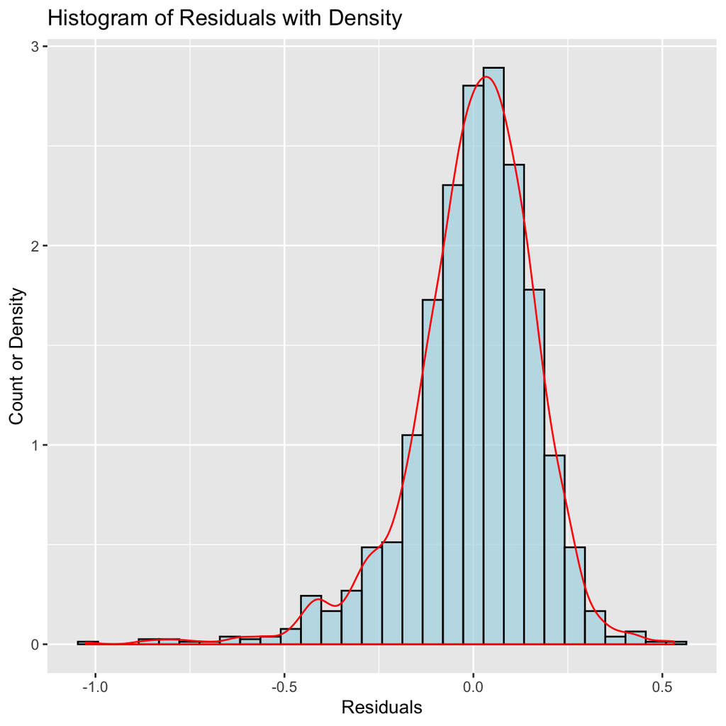

```r
lin_reg %>%
  ggplot(aes(x=resid(lin_reg))) +
  geom_histogram(aes(y=..density..),
                 fill="lightblue",color="black", alpha=0.7) +
  geom_density(color="red") +
  labs(x="Residuals", y="Count or Density",
       title="Histogram of Residuals with Density")
```

### Test Data

**Bring in the test data and predict new values.**

```r
d<- getURL(
"https://raw.githubusercontent.com/Shampjeff/cuny_msds/master/DATA_605/final_project/test.csv")
test_df<- read.csv(text=d, header = TRUE, stringsAsFactors = F)
test_df<-test_df %>%
  dplyr::select(Id, GrLivArea, TotalBsmtSF,
                OverallQual, GarageCars)
dmy <- dummyVars(" ~ .", data = test_df, fullRank = T)
test_df <- data.frame(predict(dmy, newdata = test_df))
glimpse(test_df)
```

```
Observations: 1,459
Variables: 5
$ Id          <dbl> 1461, 1462, 1463, 1464, 1465, 1466, 1467, 1468, 1469, 147…
$ GrLivArea   <dbl> 896, 1329, 1629, 1604, 1280, 1655, 1187, 1465, 1341, 882,…
$ TotalBsmtSF <dbl> 882, 1329, 928, 926, 1280, 763, 1168, 789, 1300, 882, 140…
$ OverallQual <dbl> 5, 6, 5, 6, 8, 6, 6, 6, 7, 4, 7, 6, 5, 6, 7, 9, 8, 9, 8, …
$ GarageCars  <dbl> 1, 1, 2, 2, 2, 2, 2, 2, 2, 2, 2, 1, 1, 2, 1, 3, 3, 3, 3, …
```

**Predict the Sale Price values and clean up the formatting.**

```r
preds<-predict(lin_reg, test_df)
preds<-as.data.frame(preds)
rownames(preds)<-NULL
```

**Prepare the Kaggle Data Submission.**

```r
submission_data<- as.data.frame(cbind(test_df$Id, exp(preds)))
submission_data<- submission_data %>%
  rename(Id = "test_df$Id", SalePrice = "preds") %>%
  mutate(SalePrice = replace_na(SalePrice, median(SalePrice, na.rm =T)))

DT::datatable(head(submission_data),
         extensions = c('FixedColumns',"FixedHeader"),
          options = list(scrollX = TRUE,
                         paging=TRUE,
                         fixedHeader=TRUE,
                         dom="t"))
```

|  | Id | SalePrice |
| --- | --- | --- |
| 1 | 1461 | 109614.57437262 |
| 2 | 1462 | 154205.389932029 |
| 3 | 1463 | 153707.687264736 |
| 4 | 1464 | 169006.577062794 |
| 5 | 1465 | 215446.578018493 |
| 6 | 1466 | 165517.73199108 |

```r
write.csv(submission_data, file = "Kaggle_Submit_Shamp.csv",
          quote = FALSE, row.names = FALSE)
```

**Not a great score, but we only considered a few variable of the many options. We were also constrained to multiple regression.**

**Kaggle username : jeffshamp**

**Kaggle Competition Score : 0.17735**